# Wait it’s all Markov Chain?

Always has been

Debaditya

2025-11-29

[figure not shown]

I had a course on **Stochastic Processes** this semester — my first time learning the topic. It seemed very cool and interesting, opening a completely new outlook on many statistical concepts.

Especially **Markov Chains** sparked a lot of interest in me — partly due to their usefulness, partly due to how Markov devised the idea for them (hopefully my article on that is ready by the time you’re reading this).

Since I missed one of the minor exams on this topic, I had to do something to earn some marks. The professor was nice enough to let me submit a project on **“Applications of Stochastic Processes.”**

Me being me (kinda pretentious), I had to look for something cool. So here we are — a very bold title, I guess, and wrong in many senses, but I’m just learning from Indian media (please don’t judge).In **October 2025**, the second version of the paper *“Large Language Models as Markov Chains”* came out on **arXiv**.

This write-up is mostly inspired by that paper. There’s some math and some of my personal thoughts mixed in. I’m an extreme novice in this field, so there might be plenty wrong in what I’m trying to convey — any suggestions are wholeheartedly welcome.

## The What’s

Let’s start with what we have in our hands here and what we may talk about in the article. It’s good to be ready with the definitions so that you don’t have to run around looking for them.

### What is a Markov Chain?

In simple terms (for non-math people):

> It’s a set of observations over time where the current observation depends only on what was observed last — not on any earlier observations.

A more mathematical definition would be:

> A sequence of random variables having the **Markov Property** is said to be a *Markov Chain (or Process).*

The Markov Property is:

$$P(X_{n+1} = j \mid X_n = i, X_{n-1} = i_{n-1}, \dots, X_0 = i_0)
= P(X_{n+1} = j \mid X_n = i)$$

for all $n \geq 0$ and all states $i_0, i_1, \dots, i, j$ in the state space.

This property signifies **memorylessness**.

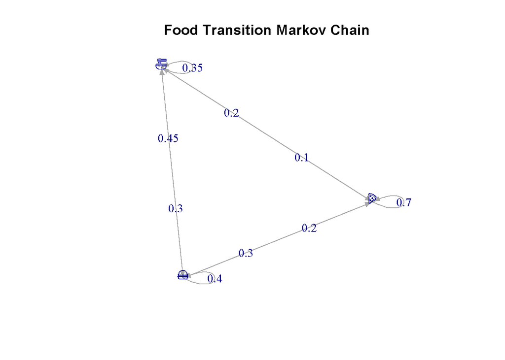

> Wish food options were actually these, but still a worthy example.

### Generalising a Bit…

A standard Markov Chain is of **order 1**, meaning the future state depends only on the immediate past state.

A **Markov Chain of order ( m )** where $m \geq 1$ is a sequence of random variables $X_n$ where the future state depends on the $ m $ previous states:

$$P(X_{n+1} \mid X_n, X_{n-1}, \dots, X_0)
= P(X_{n+1} \mid X_n, X_{n-1}, \dots, X_{n-m+1})$$

In the context of **language modeling**, this means predicting the next word depends on the ( $m$ ) preceding words — an *m-gram model*.

The complexity of modeling increases exponentially with ( $m$ ) due to the size of the transition probability matrix.

## A Little About Neural Networks

A **Neural Network (NN)** is a computational model inspired by the structure and function of biological neural networks.

It is composed of a collection of interconnected nodes (neurons or units) organized in layers — input, hidden, and output.

The basic math for Neural Networks is pretty simple — I’d recommend checking out [this article by 3b1b](https://www.3blue1brown.com/lessons/neural-networks#title)

### Recurrent Neural Networks (RNN) and Long Short-Term Memory (LSTM)

Neural Networks, in their basic form (like **Feed-Forward Networks**), treat each input independently. This is insufficient for sequence data like text, where **context matters**.

**RNNs** are a class of neural networks where connections between nodes form a **directed graph along a temporal sequence**. They have an internal loop (or recurrent connection) that allows information from previous steps to persist.

This “memory” makes them suitable for tasks like sequence prediction and **natural language processing**.

> One of the best discussions on RNNs is in a blog post by *Andrej Karpathy* — [definitely worth reading if you want to know more](https://karpathy.github.io/2015/05/21/rnn-effectiveness/).

**LSTMs (Long Short-Term Memory)** are a special type of RNN designed to overcome the **vanishing gradient problem**. They introduce a more complex internal structure called a *cell*, which can maintain information over long periods.

LSTMs are still pretty useful — although they came out long ago, they still do a decent job in **forecasting time-series data**. To know more about LSTMs, [this](https://colah.github.io/posts/2015-08-Understanding-LSTMs/) is my go-to article — do read it.

## Large Language Models

**Large Language Models (LLMs)** are powerful neural network models, typically based on the **Transformer architecture**, which uses **self-attention** instead of recurrence.

They are trained on vast amounts of text data and excel at tasks like generation, summarization, translation, and reasoning.

Here, we will focus primarily on **Autoregressive Transformer-Based LLMs**.

Although I skipped a lot of math in the previous definitions (since that would make this article very long), in the final section of the article I’ll go a bit deeper into the **mathematics** of What LLM’s,specifically autoregressive transfomer based LLM’s, are — as it’s essential for the understanding.

### So… Why Bring All of Them Together?

## The Idea

As can be seen — from **Markov Chains** to **LLMs**, all of them have sequential predicting or generating capabilities.

Specifically, **text generation** is a very interesting aspect of this, and the article will primarily focus on this — drawing some parallels between different models and **Markov Chains**.

We’ll start with a simple **n-gram** — it’s like ChatGPT but probably *schizophrenic.*

# N-Gram Language Model

A language model is a machine learning model that predicts upcoming words. More formally, a language model assigns a probability to each possible next word, or equivalently gives a probability distribution over possible next words. Language models can also assign a probability to an entire sentence. Thus an LM could tell us that the following sequence has a much higher probability of appearing in a text:

`all of a sudden I notice three guys standing on the sidewalk`

than does this same set of words in a different order:

`on guys all I of notice sidewalk three a sudden standing th`

The simplest kind of language model: the n-gram language model. An n-gram is a sequence of n words: a 2-gram (which we’ll call bigram) is a two-word sequence of words like The water, or water of, and a 3-gram (a trigram) is a three-word sequence of words like The water of, or water of Walden. But here we specifically (in a bit of terminological ambiguity) use the word ‘n-gram’ to mean a probabilistic model that can estimate the probability of a word given the n-1 previous words, and thereby also to assign probabilities to entire sequences.

## Modeling

As we defined earlier we wish to find a model of $P(w \vert h )$ where $w$ is some word and $h$ is the history prior to the word, that is we wish to find the probability of observing a certain word given the prior history.

i.e Assume our history $h$ is..

> ” The quick brown fox jumps over the lazy …”

and assume we wish to find the probability of the next word being “dog”.

One way to estimate this probability is directly from relative frequency counts: take a very large corpus, count the number of times we see The quick brown fox jumps over the lazy , and count the number of times this is followed by dog. This would be answering the question “Out of the times we saw the history h, how many times was it followed by the word $w$, as follows :

$$P(\text{dog}|\text{The quick brown fox jumps over the lazy})=\frac{C(\text{The quick brown fox jumps over the lazy dog})}{C(\text{The quick brown fox jumps over the lazy})}$$

If we had a large enough corpus we could compute these probabilities , but even the entire internet filled with books isn’t big enough to give a good estimate of counts for such, and it’s simply because of the fascinating fact that language is *creative* , new sentences, words are created every then and now.This means there is a non zero probability of the word “skibidi” or “rizz” appearing at the end of the sentence(Bad Example,but had to do it). We need a more “smarter” way to estimate this probability,that is where Mr.Markov and his genius enters.

## The Markov Assumption

The Implementation is quite simple and can be followed through this R code below, which implements a trigram model based on a second order markov assumption.

```r
txt_path <- "tiny_shakespeare.txt"
raw_text <- readLines(txt_path, warn = FALSE)
tokens <- unlist(strsplit(paste(raw_text, collapse = " "), "\\s+"))
tokens <- tokens[tokens != ""]

clean_word <- function(w) {
  w2 <- gsub("[-,.:'?;!]+", "", w)
  tolower(trimws(w2))
}

unigrams <- list()
bigrams  <- list()

n_tokens <- length(tokens)

for (idx in seq(3, n_tokens, by = 2)) {
  unigram_key <- clean_word(tokens[idx - 1])
  next_word    <- clean_word(tokens[idx])

  if (nzchar(unigram_key)) {
    if (is.null(unigrams[[unigram_key]])) {
      unigrams[[unigram_key]] <- next_word
    } else {
      unigrams[[unigram_key]] <- c(unigrams[[unigram_key]], next_word)
    }
  }

  w1 <- clean_word(tokens[idx - 2])
  w2 <- clean_word(tokens[idx - 1])
  big_key <- paste(w1, w2, sep = "||")

  if (nzchar(w1) && nzchar(w2)) {
    if (is.null(bigrams[[big_key]])) {
      bigrams[[big_key]] <- next_word
    } else {
      bigrams[[big_key]] <- c(bigrams[[big_key]], next_word)
    }
  }
}

n <- 20
big_keys <- names(bigrams)
start_big <- sample(big_keys, 1)
parts <- strsplit(start_big, "\\|\\|")[[1]]
start_succ <- sample(bigrams[[start_big]], 1)
text_words <- c(parts[1], parts[2], start_succ)

cat("text:", paste(text_words, collapse = " "))

for (i in seq_len(n)) {
  L <- length(text_words)
  prev_unigram <- text_words[L]
  prev_bigram_key <- paste(text_words[L-1], text_words[L], sep = "||")

  if (!is.null(bigrams[[prev_bigram_key]])) {
    word <- sample(bigrams[[prev_bigram_key]], 1)
  } else if (!is.null(unigrams[[prev_unigram]])) {
    word <- sample(unigrams[[prev_unigram]], 1)
  } else {
    cat("\n")
    break
  }

  cat(" ", word, sep = "")
  text_words <- c(text_words, word)
}
cat("\n")
```

The code may look a bit complicated but all it does is , removes all the whitespace and puncutations from the text –> then turns them into tokens which are just another name for each word–>At each step the code inspects the most recent context (the last two words) –> if there are observed successors for the last two-word pair (i.e. bigrams[[prev_bigram_key]] exists), sample uniformly from that successor list–>if no bigram matches, but there is a successor list for the last single word, sample from unigrams[[prev_unigram]]–>If neither context has any recorded successors, stop generation–>Each sampled word is appended to text_words, and the loop repeats

The section that enforces the Markov assumption is the decision logic in the generation loop:

```
if (!is.null(bigrams[[prev_bigram_key]])) {
  word <- sample(bigrams[[prev_bigram_key]], 1)
} else if (!is.null(unigrams[[prev_unigram]])) {
  word <- sample(unigrams[[prev_unigram]], 1)
}
```

This says: the probability distribution for the next token w_t depends only on the last 2 tokens (the bigram key) — that is a second-order Markov model (order = 2). If that 2-token context is not available, it falls back to a first-order model (depends only on the last token).

# RNN’S , LSTM’s and where Markov Chains Stand

Although there’s no direct theoretical relations between Recurrent Neural Networks their successor LSTM’s and Markov Chains.I felt the article would be incomplete if a section on them was not written, since i am extensively writing on Language Models.

Fundamentally, both approaches share a singular objective: modeling the conditional probability distribution of a sequence. While the mathematical substrates differ—one relies on discrete probability tables, the other on continuous vector space transformations—they both operate under the assumption that the future state is contingent upon the current context.

The primary distinction lies in how that context is encoded and retained.In a classical Markov model, memory is explicitly finite and discrete. An $n$-order chain considers only the immediately preceding $n$ observations, effectively discarding all prior history. This creates a rigid “horizon” of context; the model cannot account for dependencies that span beyond this fixed window. It treats language as a series of local, probable transitions rather than a cohesive narrative.

LSTMs circumvent this limitation by replacing the static transition matrix with a dynamic hidden state. Rather than looking up a probability in a table, the network learns a function to approximate it. Through its internal gating mechanisms—specifically the forget, input, and output gates—an LSTM selectively preserves or discards information over arbitrary time steps. This allows the model to maintain a persistent representation of relevant features, such as the subject of a sentence, across gaps that would render a Markov chain incoherent. Consequently, the LSTM can be viewed as an attempt to approximate a Markov process with an infinitely variable memory window, managed through learned parameters rather than hard-coded rules.

Atleast for basic text generation like tasks, vanilla RNN doesn’t differ much from markov chain based language models as can be seen from this piece of text, which includes text generated from Markov Chain based Trigram and a vanilla RNN trained on the same text.

```
DUKE VINCENTIO:
Well, your wit is in the care of side and that.
FRIAR LAURENCE:
Or walk liest;
And the ears.
And hell!
In self.
PETRUCHIO:
Persuading to our the enemy, even woman, I'll afford show'd and speaking of
England all out what least. Be satisfied! Now, sir.
Second Lord:
They would be ruled after this chamber, and
my fair nues begun out of the fact, to be conveyed,
Whose noble souls I'll have the heart of the wars.
```

As can be seen, it’s a hard task to identify which text is generated from which model, this is not to directly implicate something, obviously RNN’s have the capability to do much better with some tweaking and also for larger texts maybe we can see some noticeable difference in the text generated by both the models, but as for now the results are similiar and the extraordinary part is the explainability and light-weighted ness of the simple Markov Chain based model.

# LLM’s as Markov Chain

In this section we try to understand the theoretical standpoint of how Large Language Model’s can be expressed as an equivalent finite state Markov Chain,

Prior to this , I’ve already given some formal background on what Markov Chains and LLM’s are.

## Mathematical Definitions

**Markov chains.**

Consider a finite discrete set $\mathcal{X}$ with cardinality $|\mathcal{X}|$. We define a discrete-time, time-homogeneous Markov chain, denoted by $\text{MC}(\mathcal{X}, \mathbf{Q})$, over the state space $\mathcal{X} = \{x_i\}_{i=1}^{|\mathcal{X}|}$. The dynamics are governed by a transition matrix $\mathbf{Q} \in \mathbb{R}^{|\mathcal{X}| \times |\mathcal{X}|}$ containing entries $\mathbf{Q}_{ij} = \mathbf{Q}(x_i, x_j) \in [0, 1]$. This chain consists of a sequence of random variables $\mathbf{X}$ in $\mathcal{X}$ satisfying the Markov property; specifically, for any $n \in \mathbb{N}$ and sequence $(x_1, \ldots, x_{n+1}) \in \mathcal{X}^{n+1}$, the transition probabilities are given by:

$$\begin{split}
&\mathbb{P}(\mathbf{X}_{n+1} = x_{n+1} \mid \mathbf{X}_n = x_n, \ldots, \mathbf{X}_1 = x_1) \\
&\qquad = \mathbb{P}(\mathbf{X}_{n+1} = x_{n+1} \mid \mathbf{X}_n = x_n) \\
&\qquad := \mathbf{Q}(x_n,x_{n+1}).
\end{split}$$

A distribution $\pi$ on $\mathcal{X}$ is termed *stationary* if it satisfies the condition $\pi \mathbf{Q}= \pi$. Convergence of $\text{MC}(\mathcal{X}, \mathbf{Q})$ to $\pi$ for a starting state $x \in \mathcal{X}$ occurs if $\lim_{n \to \infty} \text{TV}(\mathbf{Q}^n(x, \cdot), \pi) = 0$. Here, $\mathbf{Q}^n(x, \cdot)$ represents the distribution of $\mathbf{X}_n$ conditioned on $\mathbf{X}_1 = x$, and the total variation distance between two distributions $\mathbb{P}$ and $\mathbb{Q}$ on a measurable space $(\Omega, \mathcal{F})$ is defined as $\text{TV}(\mathbb{P}, \mathbb{Q}) := \sup_{A \in \mathcal{F}} | \mathbb{P}(A) - \mathbb{Q}(A) |.$ The convergence rate is characterized by the mixing time $t_\text{mix}(\varepsilon)$, which is the minimum steps required to reach $\varepsilon$-proximity to the stationary distribution. Intuitively, slow mixing implies the chain remains localized near its initial state for an extended period, whereas rapid mixing indicates a swift loss of dependence on the initial condition.

**Large language models.**

We define a vocabulary $\mathcal{V}$ of size $V$ as the dictionary used to encode arbitrary sequences into discrete tokens. The model is constrained by a *context window* $T$, limiting the input length. Consequently, the domain of a transformer-based autoregressive LLM is the space of all token sequences with length at most $T$, denoted by $\mathcal{V}_T^* := \{ v \in \mathcal{V}^*,\, |v|\leq T\}$, where $|v|$ represents the length of $v$. An LLM is formally defined as a parameterized function $f_{\theta}: \mathcal{V}_T^* \rightarrow \Delta(\mathcal{V})$, with parameters $\theta$, mapping a sequence $v$ to a probability distribution over $\mathcal{V}$ (the probability simplex $\Delta(\mathcal{V})$). This output represents the likelihood of the next token given the history $v$. For notational brevity, we omit the superscripts, referring to the model simply as $f_{\theta}$. The learner’s objective is to approximate the true sequence probability distribution $\mathbb{P}_{\mathcal{L}}: \mathcal{P}(\mathcal{V}_T^*) \rightarrow [0,1]$. Furthermore, we adopt the standard assumption that there exists a constant $c_0 > 0$ such that for any $n \in [N]$ and sequence $(x_1, \ldots, x_{n+1}) \in \mathcal{X}^{n+1}$:

$$\mathbb{P}(\mathbf{X}_{n+1}=x_{n+1} \mid \mathbf{X}_n = x_n, \ldots, \mathbf{X}_1=x_1) \geq c_0.$$

**Transformer model.**

We assume $f_{\theta}$ follows a transformer architecture comprising $L$ layers and $H$ heads, structured with alternating multi-head attention (MHA) and feed-forward blocks. The processing begins with an input $\mathbf{S}^{(0)} = \mathbf{S}$ embedded in $\mathbb{R}^{d}$. To generate the vocabulary distribution, the final layer output $\mathbf{S}^{(L)} \in \mathbb{R}^{d \times n}$ undergoes projection via an “unembedding layer” $\mathbf{W}_U \in \mathbb{R}^{V \times d}$, followed by column-wise averaging to yield a vector in $\mathbb{R}^{V}$. The final next-token probability distribution is obtained via a softmax operation:

$$\mathbb{P}_{\theta}(\cdot \mid \mathbf{S}) := \mathrm{softmax}\left( \frac{1}{n \tau}\mathbf{W}_U \mathbf{S}^{(L)} \mathbf{1}_n\right) \in \Delta_{V}$$

Here, $\theta$ represents the full parameter set, $\mathbf{1}_n$ is a vector of ones of size $n$, and $\tau$ denotes the softmax temperature. Assuming the unembedding layer is bounded by a constant $B_U$, we define the feasible parameter space as $\Theta = \{ \theta \text{ s.t. } \lVert \mathbf{W}_U^\top \rVert_{2, 1} \leq B_U\}$ and the corresponding function class as $\mathcal{F} = \{ f_{\theta} \text{ s.t. } \theta \in \Theta \}$

## Large Language Models as Markov Chains

We formally define a Markov chain to capture the inference dynamics of an LLM $f_{\theta}$. We associate a tokenized input sequence with a state $v_i$, where a transition to a new state $v_j=[v_i,v]$ occurs by concatenating a predicted token $v$. This framework applies to any model with a finite vocabulary and fixed context window, including deep transformer-based LLMs.

> A small note, here temperature is to be thought of as error, i didn’t change the terminology from the paper to keep things consistent.

#### Markov Chain Formalization

First, we define sequence compatibility in the context of autoregressive prediction.

**Definition (Incompatible Sequences).** Let $u, v \in \mathcal{V}_T^*$ be two sequences of at most $T$ tokens. We define $v$ as *incompatible* with $u$ if $v$ cannot physically be a completion of $u$ due to a mismatch in history:

$$\exists l\in \{1, \ldots, |u|-1\}, \text{s.t. }(u)_{l+1} \neq (v)_l.$$

We denote the set of incompatible pairs as $\mathcal{I}$. Accordingly, we define the transition matrix associated with the LLM.

**Proposition 1 (Markov Representation).** Any large language model $f_{\theta}$ is equivalent to a Markov chain $\text{MC}(\mathcal{V}_T^*, \mathbf{Q})$ with a sparse transition matrix $\mathbf{Q} \in \mathbb{R}^{|\mathcal{V}_T^*|\times |\mathcal{V}_T^*|}$ defined for any $v_i,v_j \in \mathcal{V}_T^*$ as:

$$\mathbf{Q}(v_i, v_j) =
\begin{cases}
0, & \text{if } (v_i, v_j) \in \mathcal{I} \\
\{f_{\theta}(v_i)\}_{\text{last}}, & \text{otherwise},
\end{cases}$$

where $\{\cdot\}_{\text{last}}$ denotes the probability assigned to the last token of $v_j$. Proposition 1 implies that probability mass is only assigned to transitions between compatible sequences.

#### Properties and Convergence

We characterize the long-term behavior of this chain through the following propositions.

**Proposition 2 (Ergodicity).** The Markov chain $\text{MC}(\mathcal{V}_T^*, \mathbf{Q})$ defined in Proposition 1 is ergodic and admits a unique stationary distribution.

This implies the chain consists of a single recurrent class (sequences of maximum length $T$) and transient states (shorter sequences). We quantify the convergence rate to this equilibrium below.

**Proposition 3 (Stationary Distribution).** Let $\mathbf{e} = (1, \dots , 1)^\top$. As $n \to \infty$, $\mathbf{Q}^n$ converges to $\mathbf{e}{\pi}$, where ${\pi}$ is the stationary distribution. For all $n \geq T$:

$$\lvert (\mathbf{Q}^n)_{i,j} - (\mathbf{e}{\pi})_{i,j} \rvert \leq (1-2\varepsilon)^{\lfloor\frac{n}{T}\rfloor - 1},$$

where $\varepsilon > 0$ is the minimum transition probability within the recurrent class.

### Implications for LLMs

The theoretical framework yields two practical insights:

1. **Looping:** The stationary distribution is independent of the initial prompt. Consequently, reaching stationarity implies the model enters a deterministic loop, a known failure mode in LLMs that often necessitates repetition penalties.
2. **Temperature and Coherence:** The softmax temperature $\tau$ directly influences $\varepsilon$. Increasing $\tau$ raises the minimum transition probabilities, thereby increasing $\varepsilon$ and accelerating convergence to the stationary distribution. This theoretically explains why higher temperatures degrade long-term coherence.

## What this Means…

So, let’s break down what’s actually happening under the hood here. Think of an LLM like a giant, really complex game of dominoes or a chain link fence. The model is constantly looking at the last chunk of words it wrote to decide what comes next, but it can’t just jump to anywhere it wants. There’s a strict rule of compatibility where the end of the last sentence has to perfectly overlap with the start of the next piece. If the history doesn’t match up physically—like trying to connect “The cat sat” directly to “algebra is hard”—the model sees that move as impossible. It’s strictly locked into paths where the words flow logically from the immediate context.

So now the whole system can be explained through a Markov Chain, which is quite amazing since now we can explain the whole thing through definite probabilities. Imagine a massive map where the AI is hopping from one phrase to another. Because of that matching rule we just talked about, most paths on this map are blocked off, so the AI is funneled down specific routes.

Here is where it gets kind of trippy though. If you let the model keep generating text forever, it essentially develops amnesia. There’s this concept called a stationary distribution, which is a mathematical way of saying that eventually, the model stops caring about that original prompt you gave it and settles into a sort of “default mode.” It forgets where it started and just drifts into a stable, often repetitive state.

That actually explains two big things you’ve probably noticed when using these tools. First, you know how sometimes a bot will glitch out and just start repeating the same phrase over and over again? That’s not really a bug; it’s actually the model reaching that stable “default” state we just talked about. It gets stuck in a loop because that’s the mathematical path of least resistance. Second, if you crank up the “temperature” setting to make the AI more creative, you’re basically telling it to take riskier jumps between states. While that sounds cool, it actually makes the model reach that repetitive loop state faster. By jumping around more randomly, it forgets your instructions sooner and loses the plot, drifting into gibberish or loops way quicker than if you had kept it on a tighter leash.

# Implementation

So, we’ve talked about the math, but does it actually hold up? I ran a quick simulation of a “Toy Model” (a tiny GPT trained on a simple binary rule) to see if these Markov Chain properties actually show up in code.

Here is what happened:

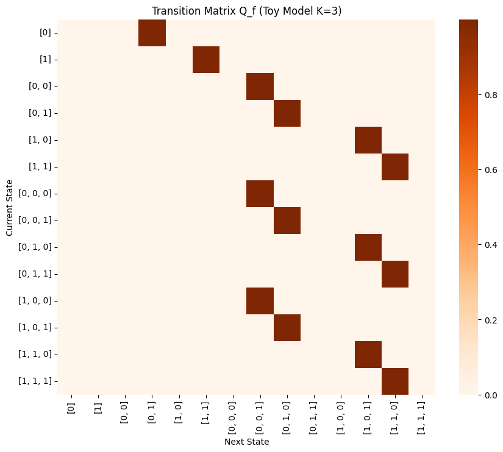

Transition Matrix of the LLM

First, check out the Transition Matrix I extracted from the model . It’s almost entirely empty space. This confirms that the model successfully learned the “compatibility” rules we talked about earlier. It realized that most transitions are impossible, effectively building its own sparse map of the language.

But the real “smoking gun” is this Convergence Graph .

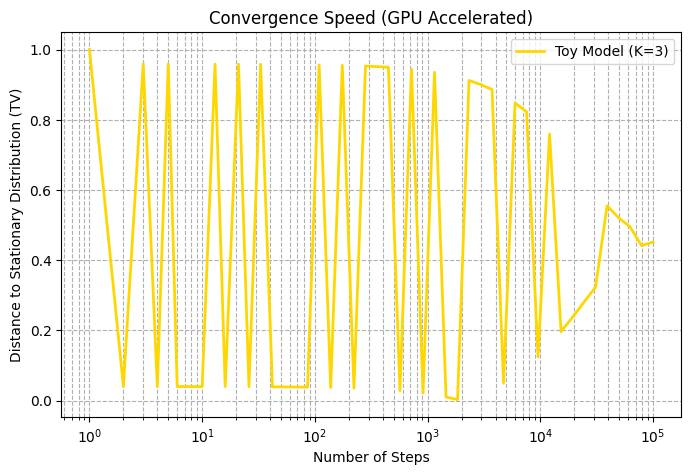

Convergence Speed

You might expect a smooth line curving down to zero, right? Instead, look at that ECG kinda thing! It’s oscillating wildly. This is experimental proof of the “Looping” phenomenon. Because the model learned the rules so perfectly, it didn’t just “settle down” into a stationary distribution; it got trapped in a hard, deterministic cycle.

This visualizes exactly why LLMs sometimes get stuck repeating the same phrase over and over again. We aren’t just looking at a bug; we are looking at the math of Markov Chains doing exactly what the equations predicted they would.

[Code for this](https://colab.research.google.com/drive/1oYAWxsjKLvX3NHNbCIHJugjH3g0q9bQS?usp=sharing)

# Hope you were not bored….

Ending the vlog in style, Here’s Markov with a thug glass created by NanoBanana, i don’t think when he was creating Markov Chains he ever thought even 100’s of years later it would still be so relevant and helpful to understand even the most complex of models. I am working on another article on how and why Markov devised the idea of Markov Chains, his thoughts and political views.

[figure not shown]

Hoping this was a good read and the reader gained some interesting learning from the whole article please feel free to reach out to me if you have any queries and also if you find something is wrong in the article, all this is based on personal research and is not reviewed properly so there could plenty of mistakes and it would be great if i can fix those :)

## References

- [Large Language Models as Markov Chains by Oussama Zekri, Ambroise Odonnat, Abdelhakim Benechehab, Linus Bleistein, Nicolas Boullé, Ievgen Redko](https://arxiv.org/abs/2410.02724)
- [Stanford Notes on Language Modeling](https://www.web.stanford.edu/~jurafsky/slp3/3.pdf)